# Social Capital Atlas Report

16 September, 2022

# Summary

This report derives from the Social Capital Atlas project developed in collaboration with *Meta*, *Opportunity Insights*, and researchers from Harvard, New York University, and Stanford [^1]. These data are nested at the highschool level. Using 21 billion riendships found from publicly available *Facebook* account information and the National Center for Education Statistics (NCES) data, SES and identify social capital constructs in students were analyzed[^2]. Measured variables include:

- Baseline measures of SES found by combining proxies for SES (e.g., median incomes in one’s residential ZIP code, cell phone model, college attended, etc.) observed on Facebook.
- The constructs of connectedness, cohesiveness, and civic engagemennt[^3].

> This document is in reference to **Pius X HS** in the zip code 68510. There are currently 1251 students enrolled at Pius X HS. Of these students, 6.7% of students volunteer.

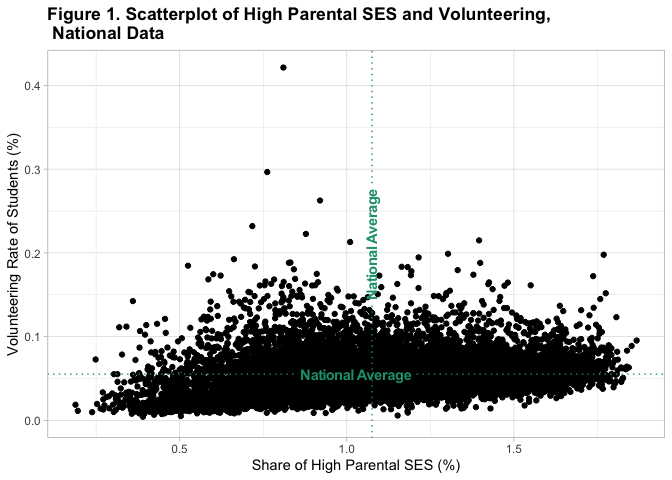

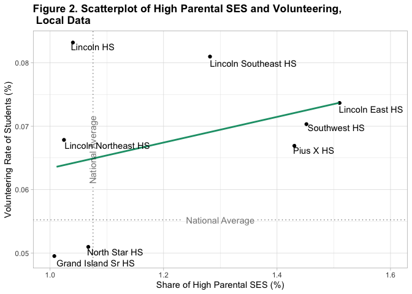

Share of high parental SES is defined as: two times the share of high-parental-SES friends (who attended the same school within three birth cohorts of the individual; “high SES” is quantified as being above the median income) among high-parental-SES individuals, averaged over all high parental-SES individuals in the school.

[^1]: Chetty, R., Jackson, M. O., Kuchler, T., Stroebel, J., Hendren, N., Fluegge, R. B., Gong, S., Gonzalez, F., Grondin, A., Jacob, M., Johnston, D., Koenen, M., Laguna-Muggenburg, E., Mudekereza, F., Rutter, T., Thor, N., Townsend, W., Zhang, R., Bailey, M., … Wernerfelt, N. (2022). Social capital I: Measurement and associations with economic mobility. Nature, 608(7921), 108–121. https://doi.org/10.1038/s41586-022-04996-4
[^2]: [Dataset](https://data.humdata.org/dataset/social-capital-atlas)
[^3]: Social Capital Website